# Template para Visualização de Dados em Bioinformática

2024-12-11

# Introdução

Este documento serve como um template e guia para:

- Como carregar e unir dados de contagem e metadados (informações sobre as bibliotecas e cepas).
- Como realizar normalizações (por exemplo, RPM - Reads Per Million).
- Como transformar dados em matriz para visualização.
- Como gerar um Heatmap de alta qualidade, entendendo cada etapa do processo e as melhores práticas em visualização.
- Como realizar um teste estatistico ANOVA.

É esperado que, ao final, voce altere esse template conforme suas necessidades, seguindo boas práticas de reprodutibilidade, clareza e padronização :)

É aconselhado que você envie posteriormente isso para o github da disciplina que será avaliado.

# Carregando Pacotes

```r
# Lista de pacotes necessários
required_packages <- c("dplyr", "reshape2", "pheatmap", "viridis")

# Função para instalar pacotes ausentes
install_if_missing <- function(pkg) {
  if (!requireNamespace(pkg, quietly = TRUE)) {
    install.packages(pkg)
  }
}

# Instalar pacotes ausentes
invisible(lapply(required_packages, install_if_missing))

# Carregar os pacotes
library(dplyr)
library(reshape2)
library(pheatmap)
library(viridis)
```

# Carregando os Dados

Este passo é crítico: certifique-se de que seus arquivos CSV estejam corretamente formatados e no diretório especificado. Ajuste os caminhos conforme necessário.

- `counts_bowtie_av0.csv`: Contagens por biblioteca e cepa (mapeadas com bowtie).
- `metadados_wolb.csv`: Informações das bibliotecas, incluindo tipo de tratamento e tamanho da biblioteca.
- `cepas_de_wolbachia.csv`: Informações sobre cada cepa de Wolbachia, incluindo um identificador único.

```r
counts_bowtie_av0 <- read.csv("C:\\Users\\victo\\Downloads\\Aula_complexheatmap\\counts_bowtie_av0.csv")
metadados_wolb    <- read.csv("C:\\Users\\victo\\Downloads\\Aula_complexheatmap\\metadados_wolb.csv")
wolbs             <- read.csv("C:\\Users\\victo\\Downloads\\Aula_complexheatmap\\cepas_de_wolbachia.csv")
```

**Boas Práticas:** - Sempre verifique se os dados foram carregados corretamente usando comandos como `head()` ou `str()`. - Mantenha nomes de arquivos e colunas padronizados e bem descritos.

# Unindo Tabelas e Preparando Dados

Nesta etapa, vamos realizar um `inner_join` entre `counts_bowtie_av0` e `metadados_wolb`. Isso permite incorporar informações adicionais (como o tipo de tratamento e o tamanho da biblioteca) diretamente ao dataset de contagens.

```r
counts_av0 <- inner_join(counts_bowtie_av0, metadados_wolb, by = "library")
head(counts_av0)
```

```
##   read_counts          cepa     library tratamento_tetraciclina lib_size
## 1         120   NC_010981.1 SRR12893564              uninfected 13201822
## 2          72   NC_018267.1 SRR12893564              uninfected 13201822
## 3          83 NZ_AP013028.1 SRR12893564              uninfected 13201822
## 4         103 NZ_CP015510.2 SRR12893564              uninfected 13201822
## 5         116 NZ_CP021120.1 SRR12893564              uninfected 13201822
## 6         638 NZ_CP031221.1 SRR12893564              uninfected 13201822
##   days_post_infection
## 1               2days
## 2               2days
## 3               2days
## 4               2days
## 5               2days
## 6               2days
```

Verifique se a junção foi bem-sucedida: agora você deve ter colunas referentes à biblioteca, contagens e metadados em um único dataframe.

# Normalização das Contagens em RPM

Para comparar diferentes bibliotecas é fundamental normalizar as contagens. Uma abordagem simples é o RPM (Reads Per Million), que ajusta as contagens pelo tamanho da biblioteca.

**Fórmula:**
$$\text{RPM} = \frac{\text{read_counts}}{\text{lib_size}} \times 10^6$$

Isso ajuda a equalizar as bibliotecas, tornando comparações mais justas.

```r
counts_av0 <- counts_av0 %>%
  mutate(RPM = (read_counts / lib_size) * 1e6)
```

Verifique com `head(counts_av0)` para assegurar que a nova coluna `RPM` foi adicionada corretamente.

# Ajustando o Identificador da Cepa

Os identificadores de cepa em `counts_av0` contêm o prefixo `"NZ_"` que não existe no dataset de Wolbachia (`wolbs`). Precisamos removê-lo para realizar um novo `inner_join` e incorporar informações da cepa (como títulos mais descritivos).

```r
counts_av0$corrected <- sub("NZ_", "", counts_av0$cepa)
counts_av0 <- inner_join(counts_av0, wolbs, by = c("corrected"="AccessionVersion"))
```

Após esse passo, `counts_av0` deve conter informações detalhadas das cepas, permitindo análises e visualizações mais ricas.

# Transformando Dados em Matriz

Para o Heatmap, geralmente trabalhamos com matrizes (linhas representando amostras, colunas representando features — neste caso, cepas). Usaremos `dcast()` para “pivotar” os dados e construir essa matriz.

- `library`: Cada linha representará uma biblioteca.
- `tratamento_tetraciclina`: Informações de tratamento serão concatenadas ao nome da linha.
- `corrected + Title_reduced`: Cada combinação dessas colunas representará uma coluna na matriz final, mostrando o valor de RPM para cada biblioteca.

```r
d_counts_av0 <- dcast(counts_av0, library + tratamento_tetraciclina ~ corrected + Title_reduced, value.var = "RPM")

# Converter em matriz numérica, removendo as colunas de texto
d_counts_av0_matrix <- as.matrix(d_counts_av0[, c(-1, -2)])

# Ajustar nomes de linha para incorporar informação de tratamento
row.names(d_counts_av0_matrix) <- paste0(d_counts_av0[, 1], "_", d_counts_av0[, 2])
```

Verifique agora a estrutura da sua matriz: `dim(d_counts_av0_matrix)` deve mostrar o número de bibliotecas (linhas) e o número de cepas/features (colunas).

# Visualização: Heatmap

**Boas Práticas para Visualização:** - Títulos e legendas claras. - Ajuste de tamanhos de fonte para legibilidade. - Uso de cores apropriadas, evitando esquemas que dificultem a distinção entre valores.

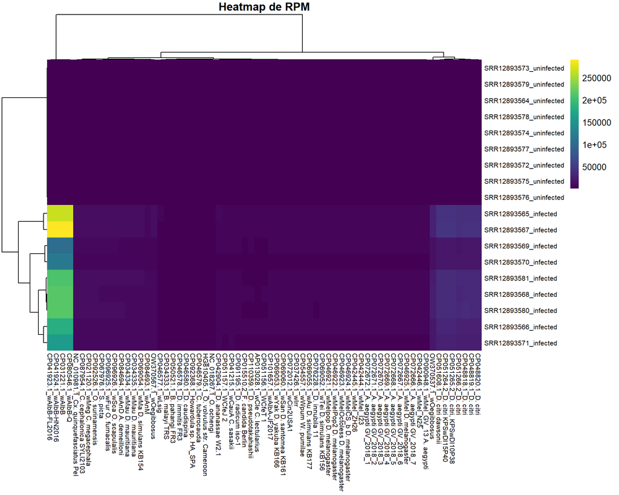

```r
# Visualização: Heatmap com pheatmap
pheatmap(
  d_counts_av0_matrix,
  color = viridis(100),                         # Paleta de cores
  main = "Heatmap de RPM",                      # Título do Heatmap
  fontsize_row = 8,                             # Tamanho da fonte das linhas
  fontsize_col = 8,                             # Tamanho da fonte das colunas
  fontsize = 10,                                # Tamanho geral da fonte
  border_color = NA                             # Remover bordas entre células
)
```

### Análise Estatística: Teste ANOVA

```r
# Converter a variável para fator, se ainda não for
counts_av0$tratamento_tetraciclina <- as.factor(counts_av0$tratamento_tetraciclina)

# Realizar o teste ANOVA
anova_result <- aov(RPM ~ tratamento_tetraciclina, data = counts_av0)

# Resumo do resultado ANOVA
anova_summary <- summary(anova_result)
anova_summary
```

```
##                           Df    Sum Sq   Mean Sq F value Pr(>F)
## tratamento_tetraciclina    1 1.033e+11 1.033e+11   91.68 <2e-16 ***
## Residuals               1204 1.356e+12 1.126e+09
## ---
## Signif. codes:  0 '***' 0.001 '**' 0.01 '*' 0.05 '.' 0.1 ' ' 1
```

### Interpretação dos Resultados

#### Hipóteses

- **$H_0$ (Hipótese Nula)**: Não há diferença significativa nos valores médios de RPM entre os grupos (tratados e não tratados com tetraciclina).
- **$H_1$ (Hipótese Alternativa)**: Existe uma diferença significativa nos valores médios de RPM entre os grupos.

#### Resultados Obtidos

- **Graus de liberdade (`Df`)**:
  - $Df_{\text{tratamento}}$: $1$ (número de grupos - 1).
  - $Df_{\text{resíduos}}$: $1204$ (total de observações - número de grupos).
- **Soma dos Quadrados (`Sum Sq`)**:
  - $1.033 \times 10^{11}$: Variabilidade explicada pelo tratamento.
  - $1.356 \times 10^{12}$: Variabilidade residual (não explicada).
- **Estatística F**:
  - $F = 91.68$: Relação entre a variabilidade explicada pelos grupos e a variabilidade residual.
- **$p$-value**:
  - $p < 2 \times 10^{-16}$: Extremamente pequeno, indicando uma diferença altamente significativa entre os grupos.

#### Conclusão

- Como $p < 0.001$, rejeitamos $H_0$ e concluímos que o tratamento com tetraciclina influencia significativamente os valores médios de RPM.
- Essa diferença observada entre os grupos tratados e não tratados não pode ser atribuída ao acaso.

# Considerações Finais

- Use a documentação do complexheatmap para melhorar a visualização de dados! O complexheatmap é o estado da arte para plotar heatmaps, varios papers de bioinfo usam e aconselho a usarem para seus proprios projetos. https://jokergoo.github.io/ComplexHeatmap-reference/book/a-single-heatmap.html
- De uma olhada no pacote de cores do Viridis, ele também é o estado da arte para paletas de cores (eu sou um apaixonado e acho super fofinho). https://www.youtube.com/watch?v=xAoljeRJ3lU